# Lecture 3 Part 1

Stats 422

## Load R libraries

```r
library(readr)
library(jsonlite)
library(dplyr)
library(ggplot2)
library(scales)
library(reticulate)
library(tidyr)
library(sf)
library(plotly)
```

# Last Time

## Begin searching

- Advisor(s)
- Data
- Keep it simple with basic tools (work towards complex)
- Exploration: one, two, then more
- It is an iterative process, so give yourself time & grace

# Data Structures

## Overview

- Data structure determines the space of possible visualizations
- Fundamental form is the rectangular (table) data
- rows = observations (records), columns = variables (fields)

## Basic Example

[Washington State EVs](https://data.wa.gov/Transportation/Electric-Vehicle-Population-Data/f6w7-q2d2/about_data)

## Front page

[figure not shown]

Home Page

## Some observations

- flat data frame, frequently stored as csv, “one row per observation”
- best use - the basics - bar charts, scatterplots, histograms, boxplots,
- many functions expect data to be in long (tidy) format — each variable is a column, each observation a row

## Let’s add Python

- Try it with OData
- Please see “using_OData_example.qmd” (see Week 3 Module)

# Activity, Break, or Both

# More complex data structures

## Tidying Data

- “Tidy Data” a 2014 article by Hadley Wickham of RStudio https://vita.had.co.nz/papers/tidy-data.pdf
- Introduced the concept of melting and casting for data transformation in R
- inspired similar operations in Python’s pandas library

## Wickham’s Main Points

- Data reshaping — converting between “wide” and “long” formats — is essential for flexible, organized and efficient data analysis
- Generally it is easier to describe the functional relationships between variables (e.g., $weight/height^2$) than between rows
- BUT it is easier to make comparisons between groups of observations in the rows than between groups of columns.

## Wickham’s Main Points (cont’d)

- Wickham writes that most datasets are not optimized for analysis. He formalizes two operations to make data more suitable for analysis:
  - Melting - convert wide data to long format (melt in pandas)
  - Casting - convert long data to wide format (pivot in pandas)

# Longitudinal Data/Panel/Repeated Measurements

## Attributes

- flat but contains multiple measurements of the same entity over time
- best use - line plots (if small), summaries by group, maybe some type of faceting
- identifiable by its grouping structure, repeated measurements, can appear “wide”
- typically pivot to long

## Basic Example - Wide

[Perception of Attractiveness](https://ucla.box.com/s/d262h7dm75lj41qsaxs9yjxm5hf8yt9m)

- This was the original dataset given to us by a consulting client
- Each row represented a “rater” who gave multiple ratings
- Consider how one might visualize this data

## Basic Example - Long

[Long or Tall format](https://ucla.box.com/s/l2asxcvrqpe67d99km6ikflt9aeut1f0)

- This is the original dataset “pivoted” for analysis
- Libraries like ggplot2 expect one column per variable, not multiple columns encoding the same kind of information
- So we make the data long so that “rating” becomes one variable, not a set of separate columns.

## Tiny Wide Example

```r
ratings_wide <- tibble(
  rater_id = 1:6,
  age = c(23, 25, 40, 38, 31, 45),
  gender = c("F", "M", "M", "F", "F", "M"),
  rating_modelA = c(4, 3, 2, 5, 4, 3),
  rating_modelB = c(3, 4, 4, 5, 5, 4),
  rating_modelC = c(5, 2, 3, 5, 4, 5)
)

ratings_wide
```

```
# A tibble: 6 × 6
  rater_id   age gender rating_modelA rating_modelB rating_modelC
     <int> <dbl> <chr>          <dbl>         <dbl>         <dbl>
1        1    23 F                  4             3             5
2        2    25 M                  3             4             2
3        3    40 M                  2             4             3
4        4    38 F                  5             5             5
5        5    31 F                  4             5             4
6        6    45 M                  3             4             5
```

## Pivot the Tiny Example

```r
ratings_long <- ratings_wide %>%
  pivot_longer(
    cols = starts_with("rating_"),
    names_to = "model",
    names_prefix = "rating_",
    values_to = "rating"
  )

ratings_long
```

```
# A tibble: 18 × 5
   rater_id   age gender model  rating
      <int> <dbl> <chr>  <chr>   <dbl>
 1        1    23 F      modelA      4
 2        1    23 F      modelB      3
 3        1    23 F      modelC      5
 4        2    25 M      modelA      3
 5        2    25 M      modelB      4
 6        2    25 M      modelC      2
 7        3    40 M      modelA      2
 8        3    40 M      modelB      4
 9        3    40 M      modelC      3
10        4    38 F      modelA      5
11        4    38 F      modelB      5
12        4    38 F      modelC      5
13        5    31 F      modelA      4
14        5    31 F      modelB      5
15        5    31 F      modelC      4
16        6    45 M      modelA      3
17        6    45 M      modelB      4
18        6    45 M      modelC      5
```

## Application - sum by group

We convert it to the basic flat rectangular structure

```r
ratings_summary <- ratings_long %>%
  group_by(model, gender) %>%
  summarise(
    mean_rating = mean(rating),
    sd_rating = sd(rating),
    n = n(),
    .groups = "drop"
  )

ratings_summary
```

```
# A tibble: 6 × 5
  model  gender mean_rating sd_rating     n
  <chr>  <chr>        <dbl>     <dbl> <int>
1 modelA F             4.33     0.577     3
2 modelA M             2.67     0.577     3
3 modelB F             4.33     1.15      3
4 modelB M             4        0         3
5 modelC F             4.67     0.577     3
6 modelC M             3.33     1.53      3
```

## Visual result

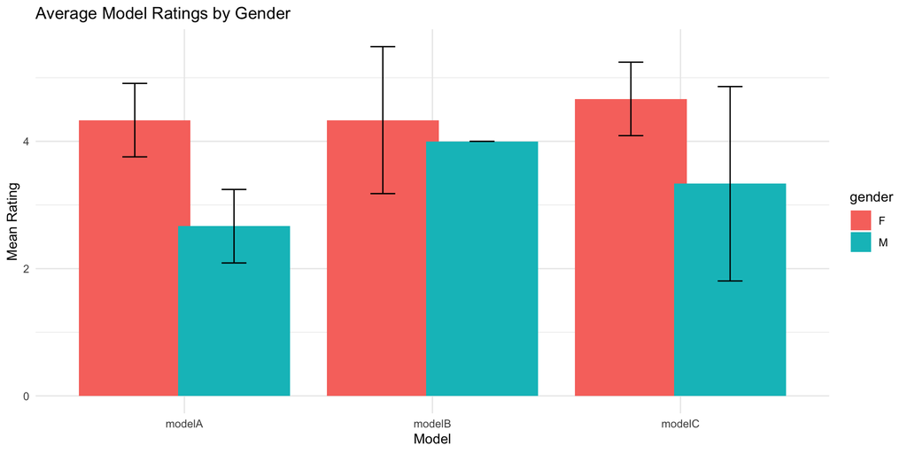

```r
ggplot(ratings_summary, aes(x = model, y = mean_rating, fill = gender)) +
  geom_col(position = position_dodge(0.8)) +
  geom_errorbar(aes(ymin = mean_rating - sd_rating,
                    ymax = mean_rating + sd_rating),
                width = 0.2,
                position = position_dodge(0.8)) +
  labs(title = "Average Model Ratings by Gender",
       x = "Model", y = "Mean Rating") +
  theme_minimal()
```

## But why bother to do this?

- Our analytic demands drive the need to tidy/reshape data
- Reshaping is rearranging data without modifying values and is less aggressive than aggregating
- Chances are, if you didn’t design or collect the data, the data that you are using conforms to another’s needs and not yours
- Data collection methods (e.g. video, survey form) are typically disconnected from the person analyzing the data

## What does it mean to tidy/reshape?

- Change the structure of data but do not change its values
  - Change how data is arranged in rows and columns
  - Transforming wide-format data to long-format data and back again
  - Flattening nested data structures into 2D tabular format
  - Reordering dimensions in multidimensional arrays

## Tabular Data vocabulary recap

- Moving between wide and Long Format
  - Wide implies many columns (e.g., repeated measurements), one obesrvation per row (usually)
  - Long implies few columns, more rows where manys row could be a single observation
  - Pivot implies making the rows columns, and making columns rows, usually within a table
  - Melt implies converting “wide” data into “long” data

## Why bother? For the specific analysis.

- Random Forest, XGBoost, Logistic Regression - typically can remain “wide”
- Visualization methods typically want the data to be “long”
- Some deep learning methods may benefit from the data being reshaped (e.g. wide to 3D array)
- EDA would probably be easier in “long” format

# Hierchical Files

## Example from Census Data

- [Canadian Census Example](https://www150.statcan.gc.ca/n1/pub/98m0001x/index-eng.htm)
- flat but contains entities within entities
- best use -
  - typically split and recombine
  - stored as JSON, nested lists, or relational tables (SQL!) joined by keys

## Example Read

Reading is straightforward

```r
library(readr)
library(ggplot2)
hier_file <- read_csv("hierarchical_file.csv")
head(hier_file)
```

```
# A tibble: 6 × 12
  HH_ID PP_ID    PR AGEGRP BEDRM  ROOM    VALUE CITIZEN GENDER TOTINC RELIG
  <dbl> <dbl> <dbl>  <dbl> <dbl> <dbl>    <dbl>   <dbl>  <dbl>  <dbl> <dbl>
1     1 11101    35     11     1     3 99999999       1      1  12000     3
2     2 21101    24     11     3     4   230000       1      2  61000     2
3     2 21102    24     11     3     4   230000       1      1  37000     2
4     3 31101    59     11     3    10  1210000       1      2  34000     3
5     3 31102    59     11     3    10  1210000       1      1  63000     9
6     4 41103    35     11     4     9  1500000       2      1  34000    88
# ℹ 1 more variable: MARSTH <dbl>
```

## Example (biased) plot

Working with hierarchical data less so. code.

```r
ggplot(hier_file, aes(x = as.factor(PR), y = ROOM, fill = as.factor(PR))) +
  geom_boxplot(alpha = 0.6) +
  labs(title = "(biased) Dwelling Size by Province",
       x = "Province",
       y = "Rooms",
       fill = "Province") +
  theme_minimal()
```

## Example (biased) plot

Finally.

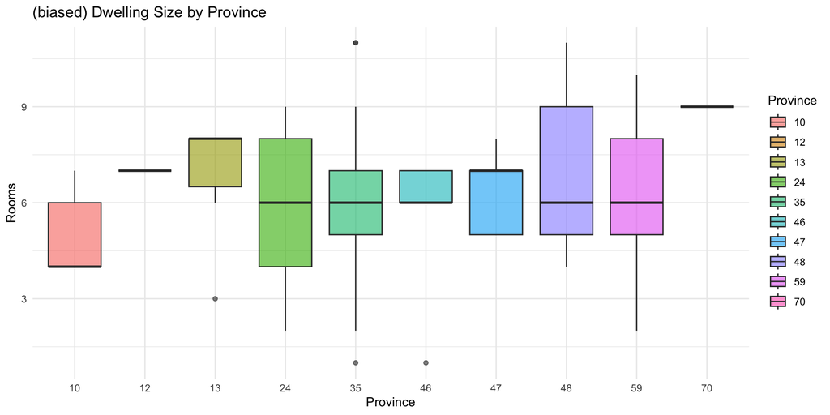

## Understanding the need to aggregate

```r
household_agg <- hier_file %>%
  mutate(across(where(is.numeric), ~ na_if(., 99999999))) %>%
  group_by(HH_ID) %>%
  summarise(
    province = first(PR),
    rooms = first(ROOM),
    hh_inc = sum(TOTINC),
    .groups = "drop"
  )

head(household_agg)
```

```
# A tibble: 6 × 4
  HH_ID province rooms hh_inc
  <dbl>    <dbl> <dbl>  <dbl>
1     1       35     3  12000
2     2       24     4  98000
3     3       59    10  97000
4     4       35     9     NA
5     5       24     2  14000
6     6       35     5     NA
```

## Less biased plot

```r
ggplot(household_agg, aes(x = as.factor(province),
                          y = rooms,
                          fill = as.factor(province))) +
  geom_boxplot(alpha = 0.6) +
  labs(title = "Dwelling Size by Province",
       x = "Province",
       y = "Rooms",
       fill = "Province") +
  theme_minimal()
```

## Less biased plot

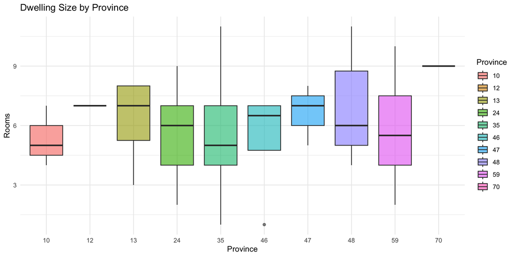

## Treemaps - visualizing hierarchical data

```r
library(treemapify)

household_agg %>%
  ggplot(aes(
    area = hh_inc,
    fill = province,
    label = HH_ID,
    subgroup = province
  )) +
  geom_treemap() +
  geom_treemap_subgroup_border(color = "white", size = 1) +
  geom_treemap_text(color = "white", place = "centre", grow = FALSE) +
  scale_fill_viridis_c() +
  labs(title = "Treemap of Households (size = household income, color = province)") +
  theme(legend.position = "right")
```

## Treemap

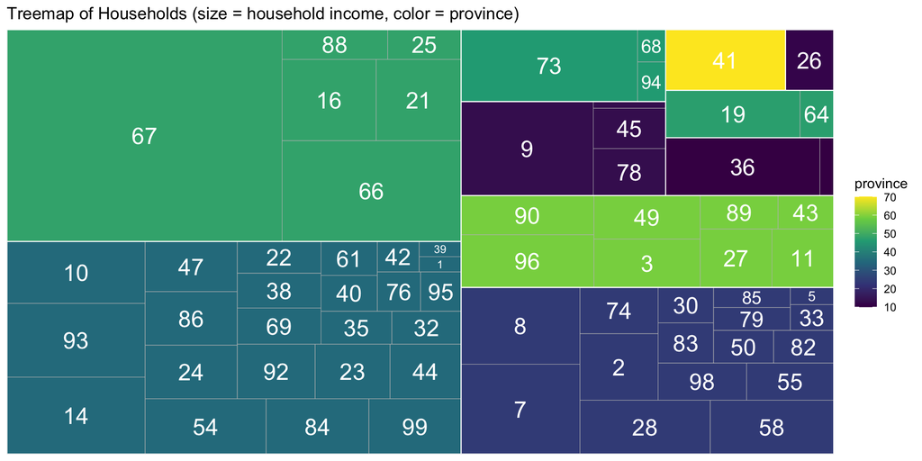

# Later this quarter

## Spatial Data Characteristics

- typically stored as hierarchical (e.g. geojson)
- coordinates, geometries, or shapefiles
- tools include choropleths, point maps

## Example

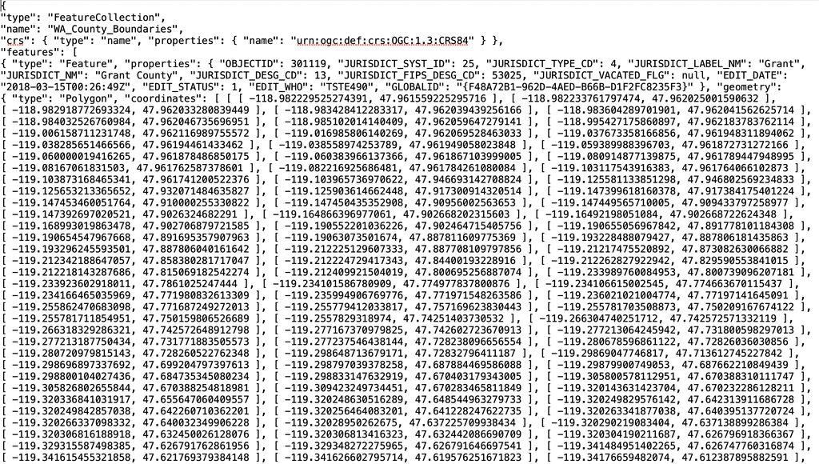

geojson

## in R

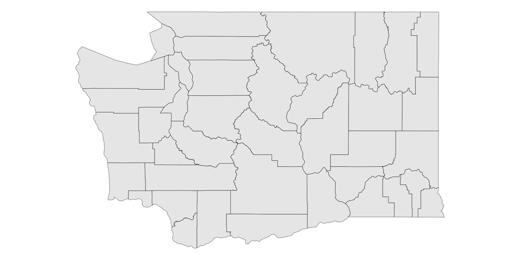

```r
geojson_basemap <- st_read("wa_counties.geojson",
                           quiet = TRUE)
ggplot() +
  geom_sf(data = geojson_basemap) +
  theme_void()
```

## What is it?

- A GeoJSON file is a JSON (JavaScript Object Notation) format designed for encoding geographic data.
- Geographical features and their properties are made human readable by using standard JSON.
- GeoJSON allows us to connect data to specific geographic features
- Widely used, platform independent, relatively easy to use

## Raster / Image Data

- GIS, remote sensing work
- GeoTIFF (.tif) is the standard filetype, open source and used everywhere
- If you download data from NASA, NOAA, USGS, etc it will be GeoTIFF

## Example

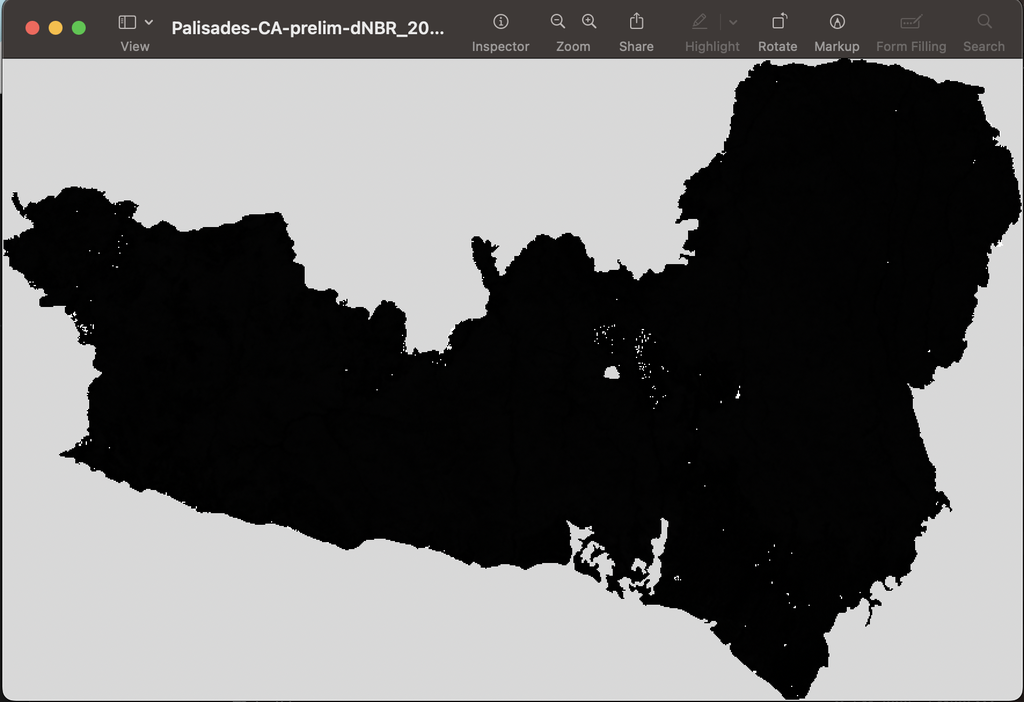

a screenshot of a GeoTIFF

## Using R/Python etc.

```r
library(terra)
library(ggplot2)

r <- rast("Palisades-CA-prelim-dNBR_20250710_235959.tif")

r
```

```
class       : SpatRaster
size        : 555, 881, 1  (nrow, ncol, nlyr)
resolution  : 20, 20  (x, y)
extent      : -2058645, -2041025, 1461785, 1472885  (xmin, xmax, ymin, ymax)
coord. ref. : USA_Contiguous_Albers_Equal_Area_Conic_USGS_version
source      : Palisades-CA-prelim-dNBR_20250710_235959.tif
name        : Palisades-CA-prelim-dNBR_20250710_235959
```

```r
summary(values(r))
```

```
 Palisades-CA-prelim-dNBR_20250710_235959
 Min.   :-32768.0
 1st Qu.:   387.0
 Median :   556.0
 Mean   :   531.1
 3rd Qu.:   690.0
 Max.   :  1188.0
 NA's   :246261
```

```r
# Convert raster to data frame for ggplot
r_df <- as.data.frame(r, xy = TRUE)
names(r_df)[3] <- "dNBR"
```

## Basic raster plot with ggplot2

```r
r_df %>%
  filter(dNBR > -100) %>%
  ggplot(aes(x = x, y = y, fill=dNBR)) +
  geom_raster() +
  coord_equal() +
  scale_fill_viridis_c(option = "C") +
  labs(
    title = "Palisades-CA dNBR (Differenced Normalized Burn Ratio)",
    fill = "dNBR"
  ) +
  theme_minimal()
```

## Result

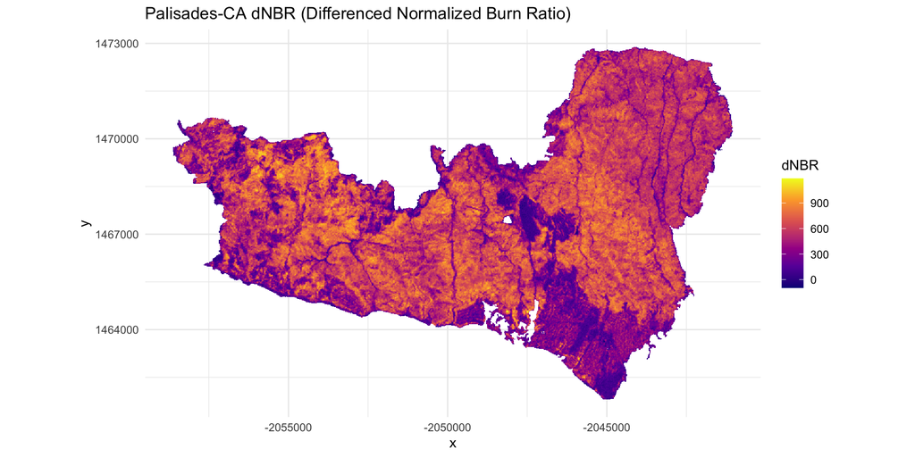

## Note

- dNBR (Differenced Normalized Burn Ratio) is an indicator of burn severity.

$$dNBR = NBR_{pre} - NBR_{post}$$

- High positive values reflect vegetation loss (burned areas)
- Negative values reflect regrowth or increased vegetation

## Time Series

- Data collected over time, measurements taken at a specific point/interval
- Order of the observations matters — shows change
- bar, line, area for single series
- side by side bar, multiple lines for comparisons
- faceting

## Example

Libraries and reading the data

```r
library(dplyr)
library(lubridate)
library(tidyr)
library(readr)
library(ggplot2)

AAPL10 <- read_csv("AAPL10.csv")
```

## Cleaning

```r
cleaned_data <- AAPL10  %>%
  mutate(
    Date = mdy(Date),
    Close = as.numeric(gsub("\\$", "", `Close/Last`)),
    Low   = as.numeric(gsub("\\$", "", Low))
  ) %>%
  arrange(Date)
```

## Plot (barplot)

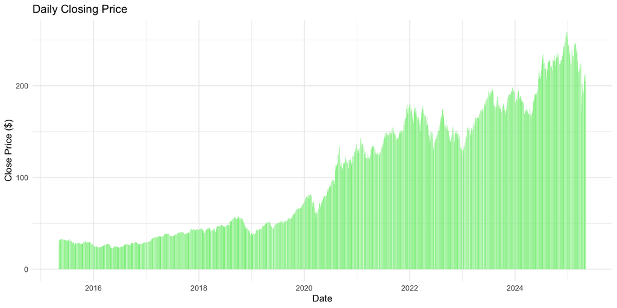

```r
ggplot(cleaned_data, aes(x = Date, y = Close)) +
  geom_col(fill = "lightgreen") +
  labs(
    title = "Daily Closing Price",
    x = "Date",
    y = "Close Price ($)"
  ) +
  theme_minimal()
```

## Alternative

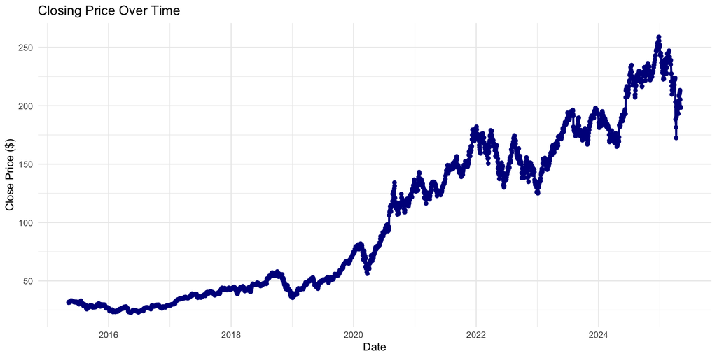

```r
ggplot(cleaned_data, aes(x = Date, y = Close)) +
  geom_line(color = "darkblue", linewidth = 1) +
  geom_point(color = "darkblue") +
  labs(
    title = "Closing Price Over Time",
    x = "Date",
    y = "Close Price ($)"
  ) +
  theme_minimal()
```

## Pivoting time series data

```r
cleaned_data_long <- AAPL10 %>%
  filter(year(mdy(Date)) == 2025) %>%
  mutate(
    Date  = mdy(Date),
    Close = as.numeric(gsub("\\$", "", `Close/Last`)),
    Low   = as.numeric(gsub("\\$", "", Low))
  ) %>%
  select(Date, Close, Low) %>%
  pivot_longer(cols = c(Close, Low), names_to = "Type", values_to = "Price") %>%
  arrange(Date)

head(cleaned_data_long)
```

```
# A tibble: 6 × 3
  Date       Type  Price
  <date>     <chr> <dbl>
1 2025-01-02 Close  244.
2 2025-01-02 Low    242.
3 2025-01-03 Close  243.
4 2025-01-03 Low    242.
5 2025-01-06 Close  245
6 2025-01-06 Low    243.
```

## Plot side-by-side bar

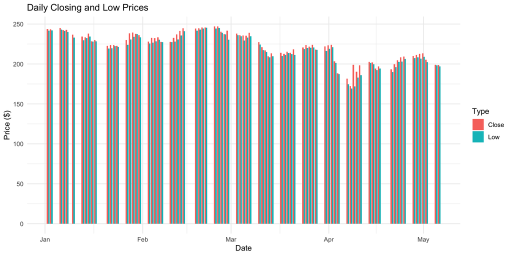

```r
ggplot(cleaned_data_long, aes(x = Date, y = Price, fill = Type)) +
  geom_col(position = "dodge") +
  labs(
    title = "Daily Closing and Low Prices",
    x = "Date",
    y = "Price ($)"
  ) +
  theme_minimal()
```

## Plot multiple lines

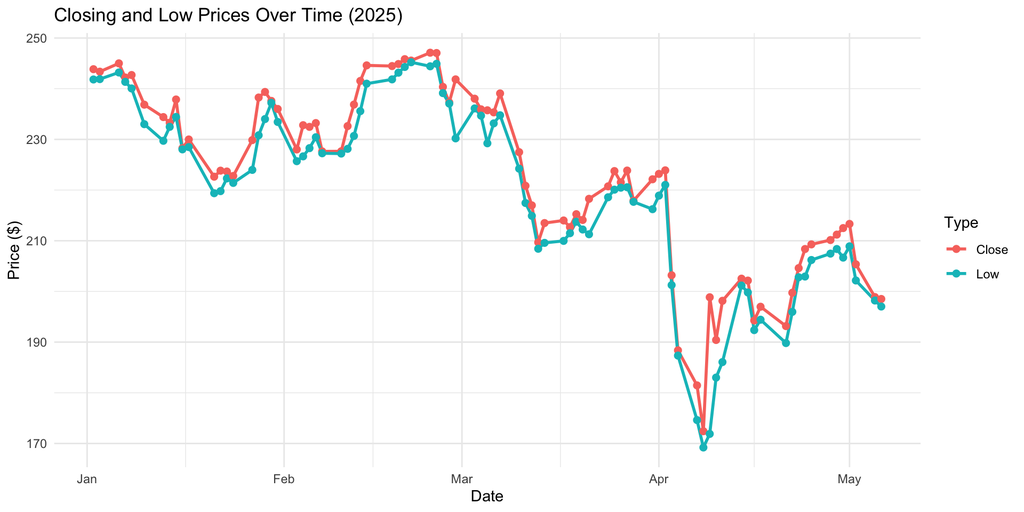

```r
ggplot(cleaned_data_long, aes(x = Date, y = Price, color = Type)) +
  geom_line(linewidth = 1) +
  geom_point(size = 2) +
  labs(
    title = "Closing and Low Prices Over Time (2025)",
    x = "Date",
    y = "Price ($)"
  ) +
  theme_minimal()
```

## Graph / Network Data

- Visualization of relationships between entities instead of tabular “rows and columns”
- Nodes (Vertices) are entities (e.g., people, places)
- Edges (Links) are relationships or connections (e.g., friendships, roads) and edges can be
  - Directed (A -> B) — e.g., YouTube “subscribers”
  - Undirected (A — B) — e.g., Facebook “friendships”
  - Weighted has a numerical value

## Example: read

```r
library(tidyverse)
library(tidygraph)
library(ggraph)
library(dplyr)
library(readr)

rel_artists <- read_csv("related_artists.csv")
head(rel_artists)
```

```
# A tibble: 6 × 7
  nominee       related_artists artist wikipedia_link followers popularity genre
  <chr>         <chr>           <chr>  <chr>              <dbl>      <dbl> <chr>
1 06HL4z0CvFAx… 6JL8zeS1NmiOft… Taylo… https://en.wi…  26530277         95 danc…
2 06HL4z0CvFAx… 1uNFoZAHBGtllm… Taylo… https://en.wi…  26530277         95 danc…
3 06HL4z0CvFAx… 6sFIWsNpZYqfjU… Taylo… https://en.wi…  26530277         95 danc…
4 06HL4z0CvFAx… 6eUKZXaKkcviH0… Taylo… https://en.wi…  26530277         95 danc…
5 06HL4z0CvFAx… 66CXWjxzNUsdJx… Taylo… https://en.wi…  26530277         95 danc…
6 06HL4z0CvFAx… 3BmGtnKgCSGYIU… Taylo… https://en.wi…  26530277         95 danc…
```

## Example: clean

```r
clean_edges <- rel_artists %>%
  filter(!is.na(nominee), !is.na(related_artists))

edges <- clean_edges %>%
  select(from = nominee, to = related_artists)
```

## Example: create nodes, clean edges

```r
# Create node table with artist attributes
nodes <- clean_edges %>%
  distinct(nominee, artist, wikipedia_link, followers, popularity) %>%
  rename(name = nominee)

clean_edges <- edges %>%
  filter(from %in% nodes$name, to %in% nodes$name)
```

## building the graph

```r
# Build tidygraph object
graph <- tbl_graph(nodes = nodes, edges = clean_edges, directed = FALSE)

# check object
graph
```

```
# A tbl_graph: 13 nodes and 35 edges
#
# An undirected multigraph with 1 component
#
# Node Data: 13 × 5 (active)
   name                   artist           wikipedia_link   followers popularity
   <chr>                  <chr>            <chr>                <dbl>      <dbl>
 1 06HL4z0CvFAxyc27GXpf02 Taylor Swift     https://en.wiki…  26530277         95
 2 66CXWjxzNUsdJxJ2JdwvnR Ariana Grande    https://en.wiki…  42023952         95
 3 1HY2Jd0NmPuamShAr6KMms Lady Gaga        https://en.wiki…  10403543         89
 4 7n2wHs1TKAczGzO7Dd2rGr Shawn Mendes     https://en.wiki…  23875330         93
 5 163tK9Wjr9P9DmM0AVK7lm Lorde            https://en.wiki…   5360126         81
 6 2wUjUUtkb5lvLKcGKsKqsR Alessia Cara     https://en.wiki…   6702852         84
 7 1uNFoZAHBGtllmzznpCI3s Justin Bieber    https://en.wiki…  32835094         96
 8 6eUKZXaKkcviH0Ku9w2n3V Ed Sheeran       https://en.wiki…  58883961         98
 9 6JL8zeS1NmiOftqZTRgdTz Meghan Trainor   https://en.wiki…   8580381         84
10 6jJ0s89eD6GaHleKKya26X Katy Perry       https://en.wiki…  14665902         88
11 6sFIWsNpZYqfjUpaCgueju Carly Rae Jepsen https://en.wiki…   3893801         78
12 0ZED1XzwlLHW4ZaG4lOT6m Julia Michaels   https://en.wiki…   2555932         87
13 25uiPmTg16RbhZWAqwLBy5 Charlie XCX      https://en.wiki…   1934472         80
#
# Edge Data: 35 × 2
   from    to
  <int> <int>
1     1     9
2     1     7
3     1    11
# ℹ 32 more rows
```

## code for graph

```r
ggraph(graph) +
  geom_edge_link(alpha = 0.3, color = "gray70") +
  geom_node_point(aes(size = followers, color = as.character(popularity))) +
  geom_node_text(aes(label = artist), repel = TRUE) +
  theme_void() +
  theme(legend.position = "none") +
  labs(title = "Artist Collaboration Network")
```

## finally!

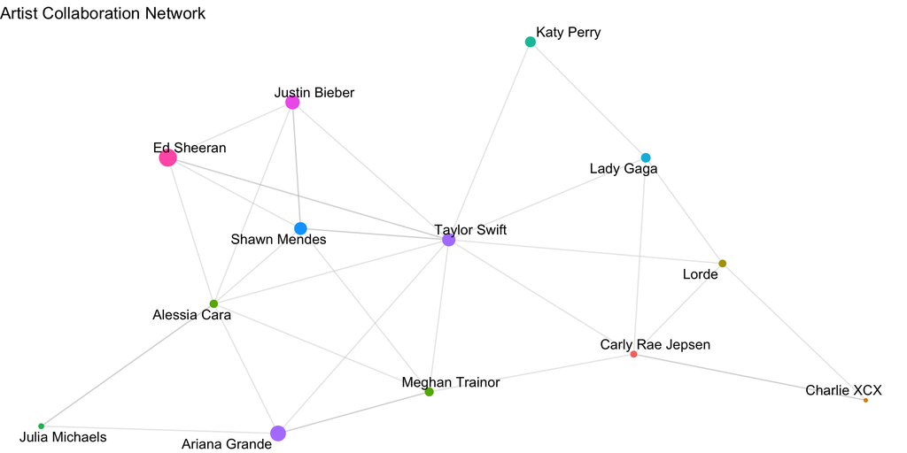